# The Verge Tech News — Text Mining & Topic Modelling

Group 01

2026-04-24

# 1 Introduction

This project performs **text mining and topic modelling** on technology news articles scraped from [The Verge](https://www.theverge.com). We collect article titles, authors, dates, and full body text from the archive, then apply natural language processing (NLP) techniques including tokenization, lemmatization, TF-IDF, and Latent Dirichlet Allocation (LDA) to discover key themes and trends in tech journalism.

# 2 Setup & Libraries

```r
packages <- c(
  "textstem", "rvest", "purrr", "dplyr", "stringr", "stringi", "topicmodels",
  "tm", "SnowballC", "tidytext", "ggplot2", "wordcloud", "RColorBrewer"
)
install.packages(packages)
```

```r
library(textstem)
library(rvest)
library(purrr)
library(dplyr)
library(stringr)
library(stringi)
library(topicmodels)
library(tm)
library(SnowballC)
library(tidytext)
library(ggplot2)
library(wordcloud)
library(RColorBrewer)
```

# 3 Data Collection (Web Scraping)

## 3.1 Text Cleaning Function

Before scraping, we define a cleaning function that standardises text encoding, removes URLs, punctuation, and extra whitespace.

```r
clean_text <- function(x) {
  x %>%
    iconv(from = "latin1", to = "UTF-8", sub = "") %>%
    stri_trans_general("latin-ascii") %>%
    str_to_lower() %>%
    str_replace_all("https?://\\S+", "") %>%
    str_replace_all("[[:punct:]]", " ") %>%
    str_replace_all("[\r\n]", " ") %>%
    str_replace_all("[^[:print:]]", " ") %>%
    str_squish()
}
```

## 3.2 Scrape Archive Pages

We scrape The Verge tech archive pages (pages 1–30), extracting article **titles**, **links**, **dates**, and **authors**.

```r
get_verge_page <- function(page_num) {
  base_url <- "https://www.theverge.com"
  url  <- paste0(base_url, "/tech/archives/", page_num)
  page <- tryCatch(read_html(url, encoding = "UTF-8"), error = function(e) NULL)
  if (is.null(page)) return(NULL)

  titles  <- page %>% html_elements("div.hp1qhq3 :not(span) > a") %>% html_text2()
  links   <- page %>% html_elements("div.hp1qhq3 :not(span) > a") %>% html_attr("href")
  dates   <- page %>% html_elements("div.hp1qhq3 time")            %>% html_attr("datetime")
  authors <- page %>% html_elements("div.hp1qhq3 span span span span") %>% html_text2()

  n <- min(length(titles), length(links), length(dates), length(authors))
  if (n == 0) return(NULL)

  tibble(
    Title  = titles[1:n],
    Link   = links[1:n],
    Date   = dates[1:n],
    Author = authors[1:n]
  )
}

page_range   <- 1:30
results_list <- list()

for (i in page_range) {
  cat("Scraping page", i, "\n")
  tmp <- get_verge_page(i)
  if (!is.null(tmp)) results_list[[length(results_list) + 1]] <- tmp
}
```

```
## Scraping page 1
## Scraping page 2
## Scraping page 3
## Scraping page 4
## Scraping page 5
## Scraping page 6
## Scraping page 7
## Scraping page 8
## Scraping page 9
## Scraping page 10
## Scraping page 11
## Scraping page 12
## Scraping page 13
## Scraping page 14
## Scraping page 15
## Scraping page 16
## Scraping page 17
## Scraping page 18
## Scraping page 19
## Scraping page 20
## Scraping page 21
## Scraping page 22
## Scraping page 23
## Scraping page 24
## Scraping page 25
## Scraping page 26
## Scraping page 27
## Scraping page 28
## Scraping page 29
## Scraping page 30
```

```r
result <- bind_rows(results_list)
cat("Total raw rows scraped:", nrow(result), "\n")
```

```
## Total raw rows scraped: 361
```

## 3.3 Scrape Article Body Text

For each article link we scrape the full body text and apply the cleaning function.

```r
get_article_text <- function(url) {
  tryCatch({
    page       <- read_html(url, encoding = "UTF-8")
    paragraphs <- page %>%
      html_elements("div.duet--article--article-body-component p") %>%
      html_text2()
    clean_text(paste(paragraphs, collapse = " "))
  }, error = function(e) NA)
}
```

# 4 Data Cleaning

## 4.1 Filter & Standardise Links

We remove rows with missing fields, fix relative URLs, and keep only links pointing to The Verge domain.

```r
base_url <- "https://www.theverge.com"

results <- result %>%
  filter(
    !is.na(Title),  Title  != "",
    !is.na(Link),   Link   != "",
    !is.na(Date),   Date   != "",
    !is.na(Author), Author != "",
    !str_detect(Link, "^#")
  ) %>%
  mutate(Link = if_else(str_detect(Link, "^https?://"), Link, str_c(base_url, Link))) %>%
  distinct(Link, .keep_all = TRUE) %>%
  filter(str_detect(Link, "^https?://([a-zA-Z0-9-]+\\.)?theverge\\.com"))

# Remove placeholder author "and"
results1 <- results %>% filter(Author != "and")
```

## 4.2 Fetch Article Text & Clean Fields

```r
results1$ArticleText <- map_chr(results1$Link, possibly(get_article_text, NA_character_))

results1 <- results1 %>%
  mutate(
    Title       = clean_text(Title),
    Author      = clean_text(Author),
    ArticleText = clean_text(ArticleText)
  ) %>%
  filter(!is.na(ArticleText), ArticleText != "")

cat("Articles with text:", nrow(results1), "\n")
```

```
## Articles with text: 127
```

## 4.3 Clean Dates

```r
results1 <- results1 %>%
  mutate(Date_clean = suppressWarnings(as.Date(Date))) %>%
  filter(!is.na(Date_clean)) %>%
  mutate(Date = Date_clean) %>%
  select(-Date_clean)

cat("Date range:", as.character(min(results1$Date)),
    "to", as.character(max(results1$Date)), "\n")
```

```
## Date range: 2026-01-26 to 2026-04-23
```

## 4.4 Preview Cleaned Dataset

```r
head(results1 %>% select(Title, Author, Date))
```

```
## # A tibble: 6 × 3
##   Title                                                        Author Date
##   <chr>                                                        <chr>  <date>
## 1 leak reveals new xbox game pass a starter editiona thata s … tom w… 2026-04-23
## 2 claude is connecting directly to your personal apps like sp… stevi… 2026-04-23
## 3 scrapped microsoft gaming in favor of xbox                   tom w… 2026-04-23
## 4 all hands meeting                                            rober… 2026-04-23
## 5 pro                                                          tom w… 2026-04-23
## 6 horizon tv hub                                               tom w… 2026-04-23
```

# 5 Tokenization & Lemmatization

We tokenize the article text into individual words, remove standard and custom stop words, keep only alphabetic tokens, and then lemmatize each word (reduce to its base form).

```r
custom_stopwords <- c("ita", "verge", "tech", "said", "will", "youa", "ia", "thata", "wea")

tokens <- results1 %>%
  select(Link, ArticleText) %>%
  unnest_tokens(word, ArticleText) %>%
  filter(!word %in% stop_words$word) %>%
  filter(!word %in% custom_stopwords) %>%
  filter(str_detect(word, "^[a-z]+$")) %>%
  mutate(word = lemmatize_words(word))

cat("Total tokens after cleaning:", nrow(tokens), "\n")
```

```
## Total tokens after cleaning: 39900
```

# 6 Word Frequency Analysis

## 6.1 Top 20 Most Frequent Words

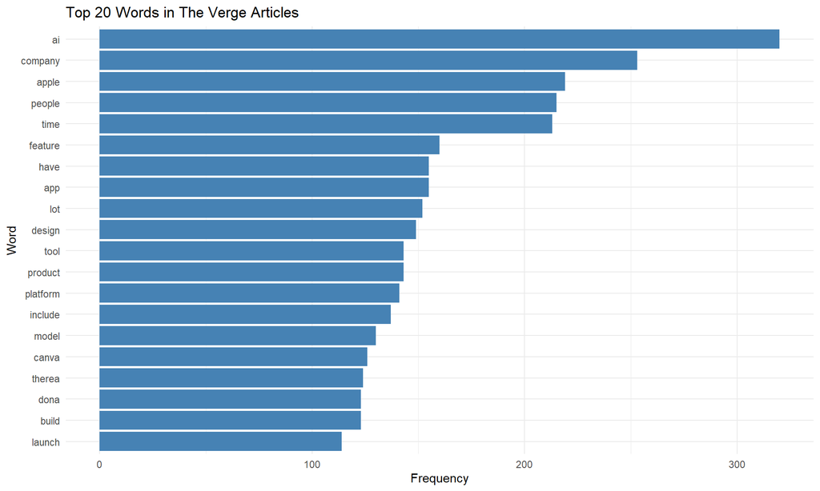

```r
word_freq <- tokens %>%
  count(word, sort = TRUE) %>%
  top_n(20, n)

ggplot(word_freq, aes(x = reorder(word, n), y = n)) +
  geom_bar(stat = "identity", fill = "steelblue") +
  coord_flip() +
  labs(title = "Top 20 Words in The Verge Articles",
       x = "Word", y = "Frequency") +
  theme_minimal()
```

## 6.2 Word Cloud (Top 80 Words)

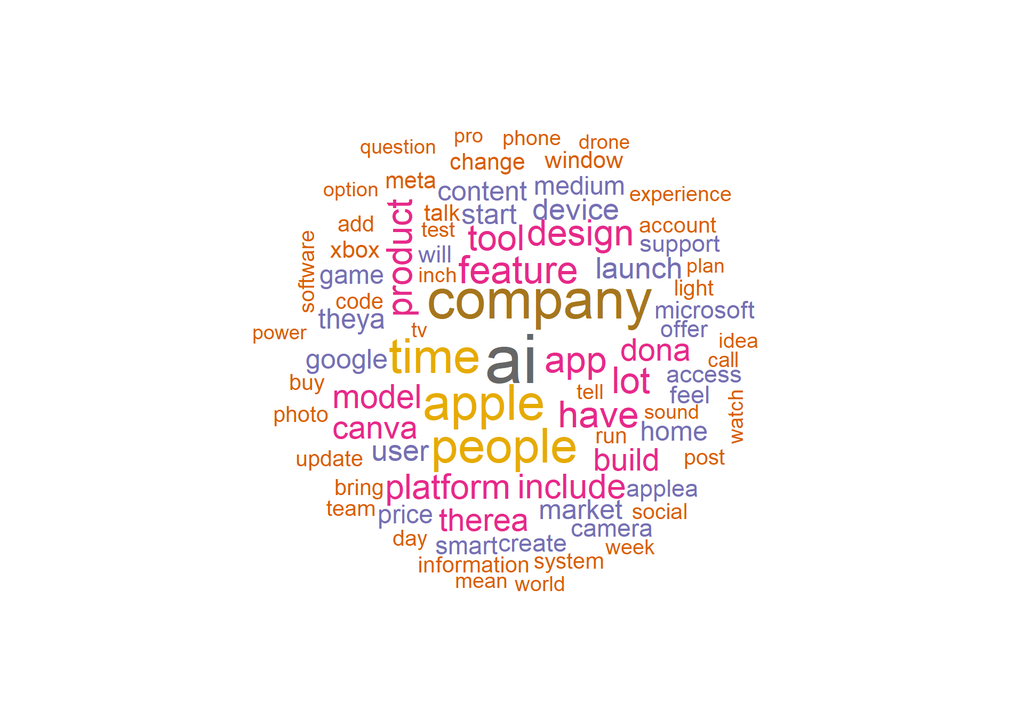

```r
custom_word_freq <- tokens %>%
  count(word, sort = TRUE) %>%
  top_n(80, n)

wordcloud(
  words        = custom_word_freq$word,
  freq         = custom_word_freq$n,
  min.freq     = 2,
  max.words    = 500,
  random.order = FALSE,
  colors       = brewer.pal(8, "Dark2")
)
```

# 7 TF-IDF Analysis

**TF-IDF** (Term Frequency–Inverse Document Frequency) measures how important a word is to a specific article relative to all articles. High TF-IDF words are distinctive to that article.

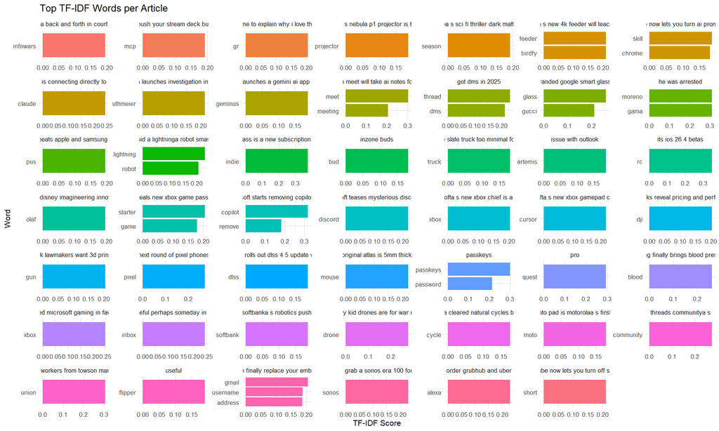

```r
tfidf <- tokens %>%
  count(Link, word) %>%
  bind_tf_idf(word, Link, n)

# Top 5 TF-IDF words per article, joined with titles
top_tfidf <- tfidf %>%
  group_by(Link) %>%
  slice_max(tf_idf, n = 5) %>%
  ungroup() %>%
  left_join(results1 %>% select(Link, Title), by = "Link") %>%
  mutate(Title_short = str_trunc(Title, 40))

# Sample: top ~12 articles
tfidf_sample <- top_tfidf %>%
  group_by(Title_short) %>%
  slice_max(tf_idf, n = 5) %>%
  ungroup() %>%
  slice_max(tf_idf, n = 60)

ggplot(tfidf_sample, aes(x = reorder_within(word, tf_idf, Title_short),
                          y = tf_idf, fill = Title_short)) +
  geom_col(show.legend = FALSE) +
  facet_wrap(~ Title_short, scales = "free") +
  scale_x_reordered() +
  coord_flip() +
  labs(title = "Top TF-IDF Words per Article",
       x = "Word", y = "TF-IDF Score") +
  theme_minimal(base_size = 8)
```

# 8 Document-Term Matrix

We build a **Document-Term Matrix (DTM)** where each row is an article and each column is a word. This is required for LDA topic modelling.

```r
dtm <- tokens %>%
  count(Link, word) %>%
  cast_dtm(document = Link, term = word, value = n)

cat("DTM dimensions:", dim(dtm)[1], "documents x", dim(dtm)[2], "terms\n")
```

```
## DTM dimensions: 127 documents x 6715 terms
```

# 9 Topic Modelling (LDA)

**Latent Dirichlet Allocation (LDA)** is an unsupervised machine learning technique that discovers hidden topics in a collection of documents. Each topic is a probability distribution over words.

We set **k = 6 topics**.

```r
set.seed(123)
k         <- 6
lda_model <- LDA(dtm, k = k, control = list(seed = 123))

lda_terms <- tidy(lda_model, matrix = "beta")   # word-topic probabilities
lda_docs  <- tidy(lda_model, matrix = "gamma")  # doc-topic probabilities
```

## 9.1 Top Terms per Topic

Each bar shows the top 10 words most associated with each topic (by beta probability).

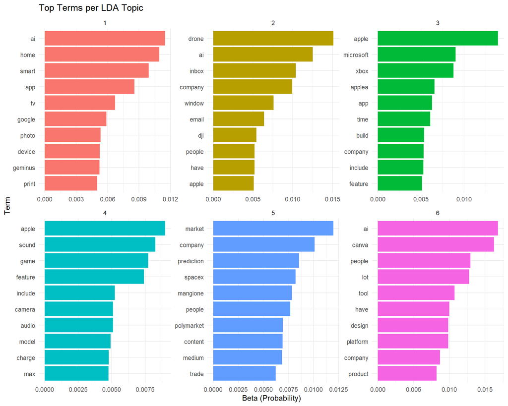

```r
top_terms <- lda_terms %>%
  group_by(topic) %>%
  slice_max(beta, n = 10) %>%
  ungroup() %>%
  arrange(topic, -beta)

ggplot(top_terms, aes(x = reorder_within(term, beta, topic),
                       y = beta, fill = factor(topic))) +
  geom_col(show.legend = FALSE) +
  facet_wrap(~ topic, scales = "free") +
  scale_x_reordered() +
  coord_flip() +
  labs(title = "Top Terms per LDA Topic",
       x = "Term", y = "Beta (Probability)") +
  theme_minimal()
```

## 9.2 Most Common Topics Across Articles

This chart shows how many articles are primarily associated with each topic.

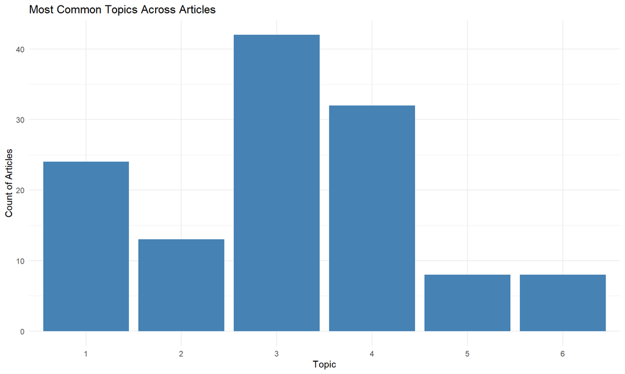

```r
doc_topics <- lda_docs %>%
  group_by(document) %>%
  slice_max(gamma, n = 1) %>%
  ungroup()

ggplot(doc_topics, aes(x = factor(topic))) +
  geom_bar(fill = "steelblue") +
  labs(title = "Most Common Topics Across Articles",
       x = "Topic", y = "Count of Articles") +
  theme_minimal()
```

## 9.3 Word Clouds per Topic

A word cloud for each of the 6 LDA topics, where word size reflects the beta probability.

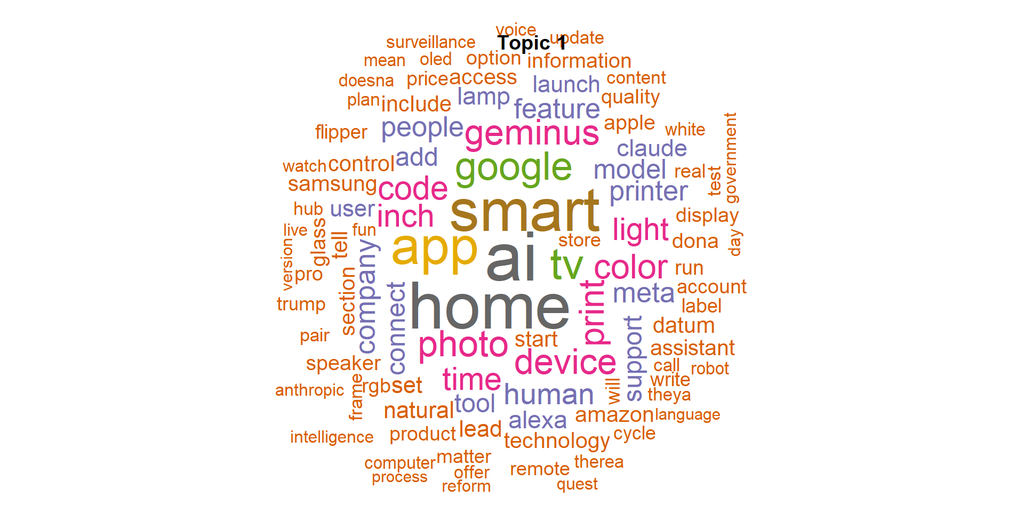

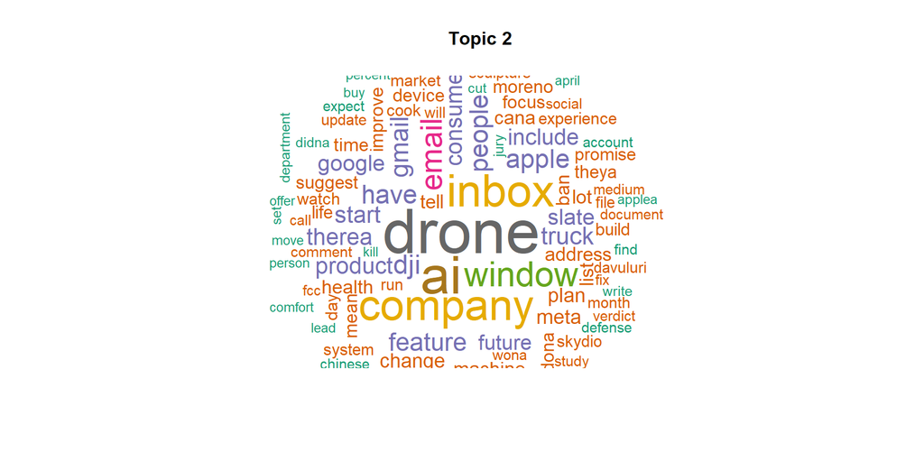

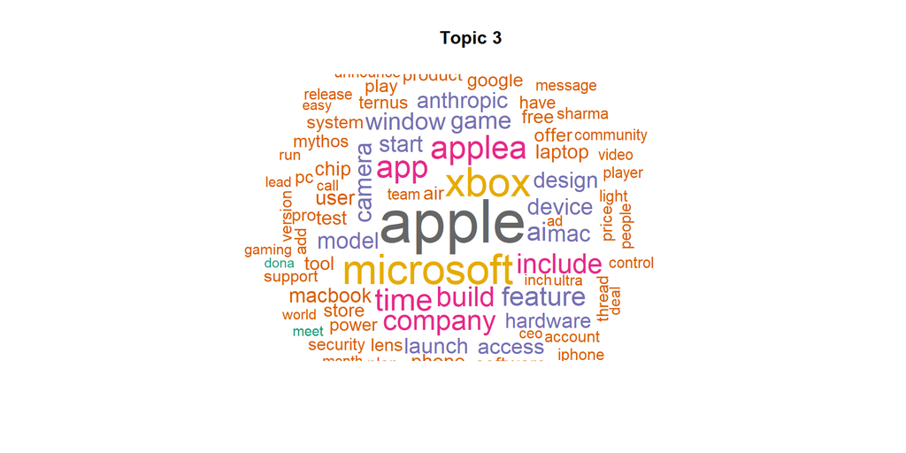

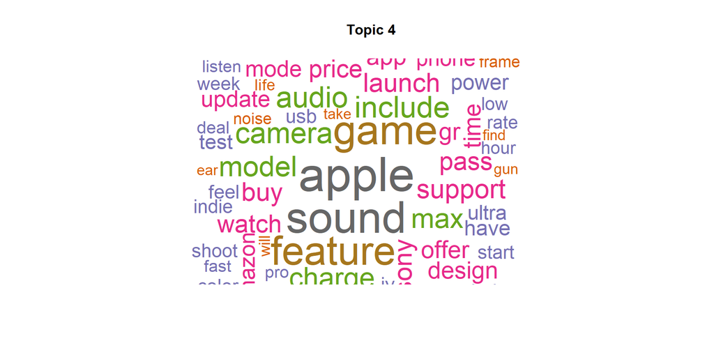

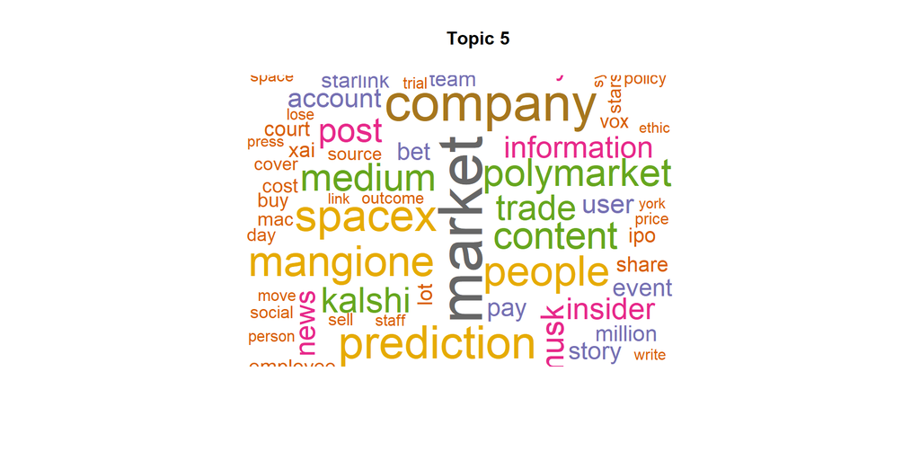

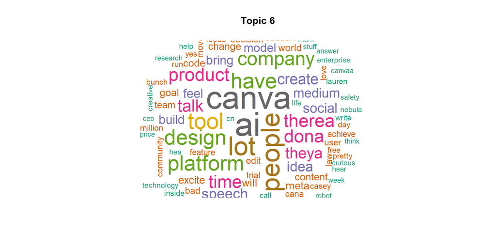

```r
for (i in 1:k) {
  terms_topic <- lda_terms %>%
    filter(topic == i) %>%
    arrange(desc(beta))

  wordcloud(
    words        = terms_topic$term,
    freq         = terms_topic$beta,
    max.words    = 100,
    colors       = brewer.pal(8, "Dark2"),
    random.order = FALSE,
    main         = paste("Topic", i)
  )
  title(paste("Topic", i))
}
```

# 10 Trend Analysis

## 10.1 Number of Articles Published Over Time

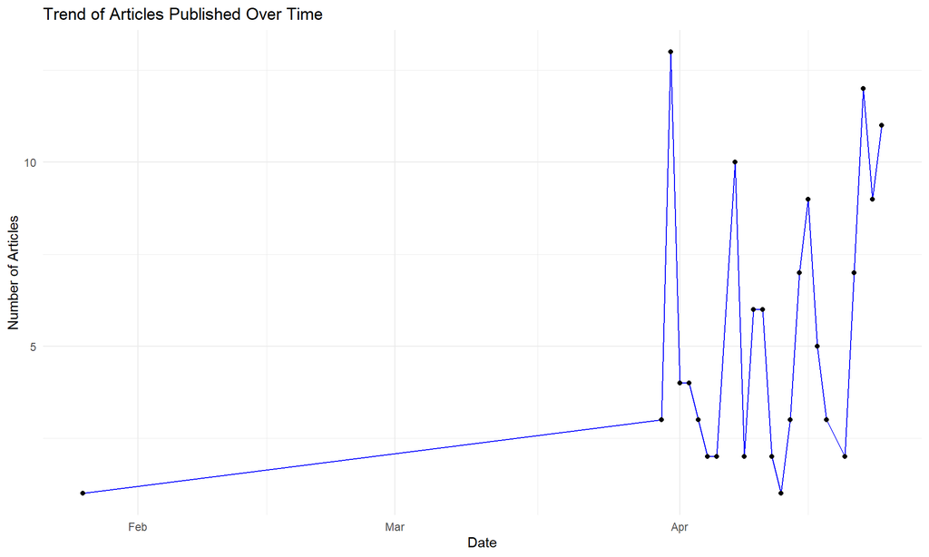

```r
trend_data <- results1 %>% count(Date)

ggplot(trend_data, aes(x = Date, y = n)) +
  geom_line(color = "blue") +
  geom_point() +
  labs(title = "Trend of Articles Published Over Time",
       x = "Date", y = "Number of Articles") +
  theme_minimal()
```

# 11 Save Outputs

The cleaned dataset, TF-IDF scores, and DTM are saved as CSV files. **Update the paths below to match your local machine.**

```r
write.csv(results1,          "clean_news2.csv",   row.names = FALSE)
write.csv(tfidf,             "tfidf_verge.csv",   row.names = FALSE)
write.csv(as.matrix(dtm),    "dtm_verge.csv")

cat("Saved", nrow(results1), "records to clean_news2.csv\n")
cat("Saved TF-IDF data to tfidf_verge.csv\n")
cat("Saved DTM to dtm_verge.csv\n")
```

# 12 Conclusion

This project scraped and analysed technology news articles from The Verge using text mining and NLP techniques. Key findings include:

- The most frequent terms across all articles reflect dominant tech topics such as AI, software, devices, and companies.
- **TF-IDF** analysis revealed that each article has a distinctive vocabulary that differentiates it from others.
- **LDA topic modelling** successfully identified 6 latent topics, capturing themes such as consumer electronics, AI/software, policy, and media.
- **Publication trends** show variation in article volume over the scraped time period.

This type of analysis is valuable for understanding media focus, tracking emerging tech trends, and building recommendation or classification systems.